# examples_0326

Consider the $L$-system (and turn angle) defined below:

- Start: `A++++A`
- Rules:  
  `A > +A-B-B[B]`  
  `B > -B+A+A[A]`
- Number of recursions (number of iterations):
  - 5
- Turn angle
  - 45°

Please use [this online tool](https://artockthedino.github.io/lsys.html) to generate the pattern using turtle graphics. Choose the matching pattern. (The initial angle should be $270$ degrees to match the orientation.)

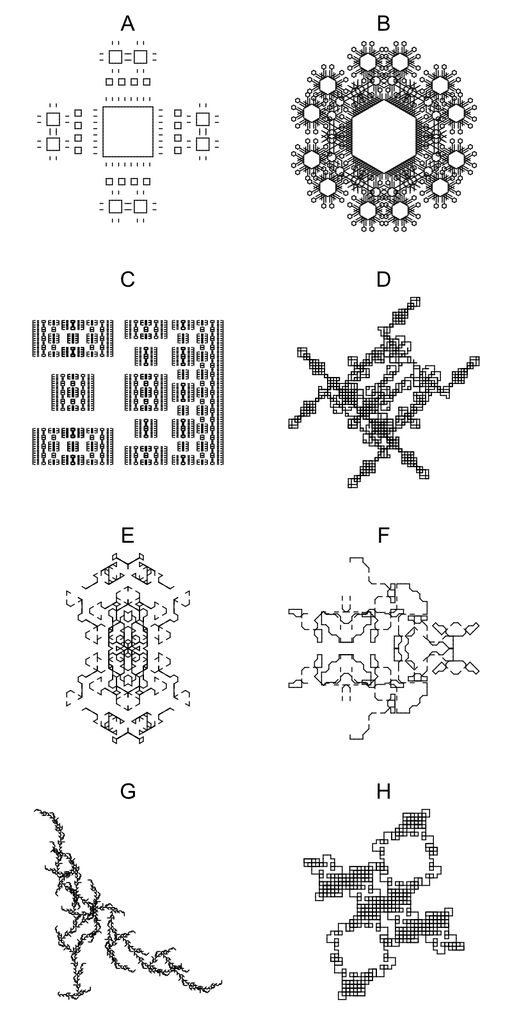

ABCDEFGH

The correct pattern is pattern G.

1. Use the first link: https://artockthedino.github.io/lsys.html
2. Copy/paste the `Axiom`, `Rules`, `Iterations`, and `Turn angle`.
3. Click `Generate Pattern`
4. Back to the quiz, select the matching pattern.

In case you're interested in the parameters of the other patterns shown:

## Pattern A

- Start: `A`
- Rules:  
  `A > XXX-B+BB+BB+BB+B`  
  `X > XX`  
  `B > B[-XXA]B`
- Number of recursions (number of iterations):
  - 4
- Angle
  - 90

## Pattern B

- Start: `A`
- Rules:  
  `A > -B+B+B+B+B+B`  
  `B > B[--CCA][-CCA]B`  
  `C > CC`
- Number of recursions (number of iterations):
  - 5
- Angle
  - 60

## Pattern C

- Start: `A`
- Rules:  
  `A > +BX-AA-XB+`  
  `B > -AX+B+XA-`  
  `X > XX`
- Number of recursions (number of iterations):
  - 7
- Angle
  - 90

## Pattern D

- Start: `A`
- Rules:  
  `A > A--CBC--A`  
  `B > B+C+B`  
  `C > -CB+BC-`
- Number of recursions (number of iterations):
  - 6
- Angle
  - 90

## Pattern E

- Start: `AA`
- Rules:  
  `A > +B-AXB---ACA---BXA-B+`  
  `B > -A++BXA+C+AXB++A-`  
  `C > C+C`  
  `X > XXX`
- Number of recursions (number of iterations):
  - 3
- Angle
  - 60

## Pattern F

- Start: `A`
- Rules:  
  `A > AXB+C+BXA`  
  `B > C--BAB--C`  
  `C > B+D-A-D+B`  
  `X > XX`  
  `D > DD`
- Number of recursions (number of iterations):
  - 4
- Angle
  - 45

## Pattern G

- Start: `A++++A`
- Rules:  
  `A > +A-B-B[B]`  
  `B > -B+A+A[A]`
- Number of recursions (number of iterations):
  - 5
- Angle
  - 45

## Pattern H

- Start: `AA`
- Rules:  
  `A > B-AA-B`  
  `B > AB+B+A`
- Number of recursions (number of iterations):
  - 5
- Angle
  - 90

Consider the $L$-system (and turn angle) defined below:

- Start: `A`
- Rules:  
  `A > XXX-B+BB+BB+BB+B`  
  `X > XX`  
  `B > B[-XXA]B`
- Number of recursions (number of iterations):
  - 4
- Turn angle
  - 90°

Please use [this online tool](https://artockthedino.github.io/lsys.html) to generate the pattern using turtle graphics. Choose the matching pattern. (The initial angle should be $270$ degrees to match the orientation.)

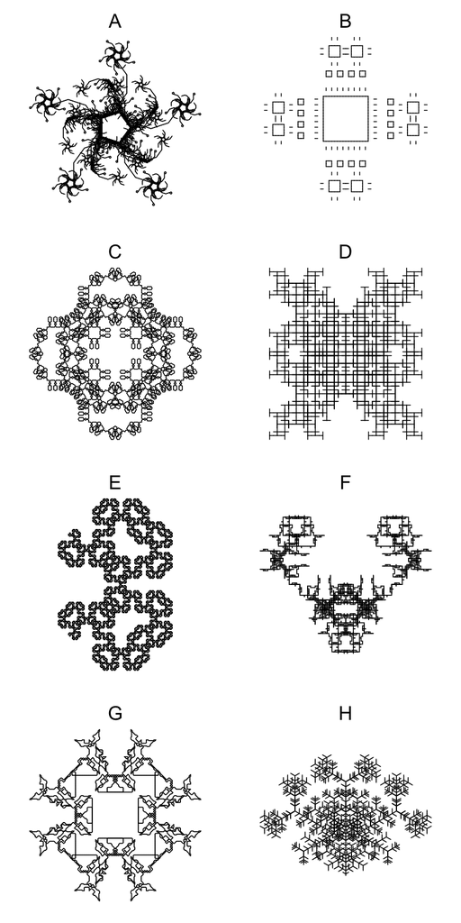

ABCDEFGH

The correct pattern is pattern B.

1. Use the first link: https://artockthedino.github.io/lsys.html
2. Copy/paste the `Axiom`, `Rules`, `Iterations`, and `Turn angle`.
3. Click `Generate Pattern`
4. Back to the quiz, select the matching pattern.

In case you're interested in the parameters of the other patterns shown:

## Pattern A

- Start: `A`
- Rules:  
  `A > B++B++B++B++B`  
  `B > B[-CCC-CC-CCA][----CC-CCB]B`  
  `C > CC`
- Number of recursions (number of iterations):
  - 5
- Angle
  - 36

## Pattern B

- Start: `A`
- Rules:  
  `A > XXX-B+BB+BB+BB+B`  
  `X > XX`  
  `B > B[-XXA]B`
- Number of recursions (number of iterations):
  - 4
- Angle
  - 90

## Pattern C

- Start: `A+++A+++A+++A`
- Rules:  
  `A > B--B`  
  `B > AA+++AA`
- Number of recursions (number of iterations):
  - 7
- Angle
  - 30

## Pattern D

- Start: `A++A`
- Rules:  
  `A > AB[-A][+A]`  
  `B > A`
- Number of recursions (number of iterations):
  - 6
- Angle
  - 90

## Pattern E

- Start: `A`
- Rules:  
  `A > +BA-ABA-AB+`  
  `B > -AB+BAB+BA-`
- Number of recursions (number of iterations):
  - 5
- Angle
  - 90

## Pattern F

- Start: `-A`
- Rules:  
  `A > +BA+A-ABA-A+AB+`  
  `B > +BBA-B--B-ABB+`
- Number of recursions (number of iterations):
  - 4
- Angle
  - 90

## Pattern G

- Start: `AAAA`
- Rules:  
  `A > +BA+A-ABCBA-A+AB+`  
  `B > +BBA-B-CCCC-B-ABB+`  
  `C > CCCCC`
- Number of recursions (number of iterations):
  - 3
- Angle
  - 45

## Pattern H

- Start: `A`
- Rules:  
  `A > A[-BC][+BC]BC`  
  `B > BB[-ABC][+ABC]`  
  `C > CCC[-CBA][+CBA]`
- Number of recursions (number of iterations):
  - 4
- Angle
  - 60

Consider the $L$-system (and turn angle) defined below:

- Start: `A`
- Rules:  
  `A > A--CBC--A`  
  `B > B+A+B`  
  `C > -CB+BC-`
- Number of recursions (number of iterations):
  - 7
- Turn angle
  - 90°

Please use [this online tool](https://artockthedino.github.io/lsys.html) to generate the pattern using turtle graphics. Choose the matching pattern. (The initial angle should be $270$ degrees to match the orientation.)

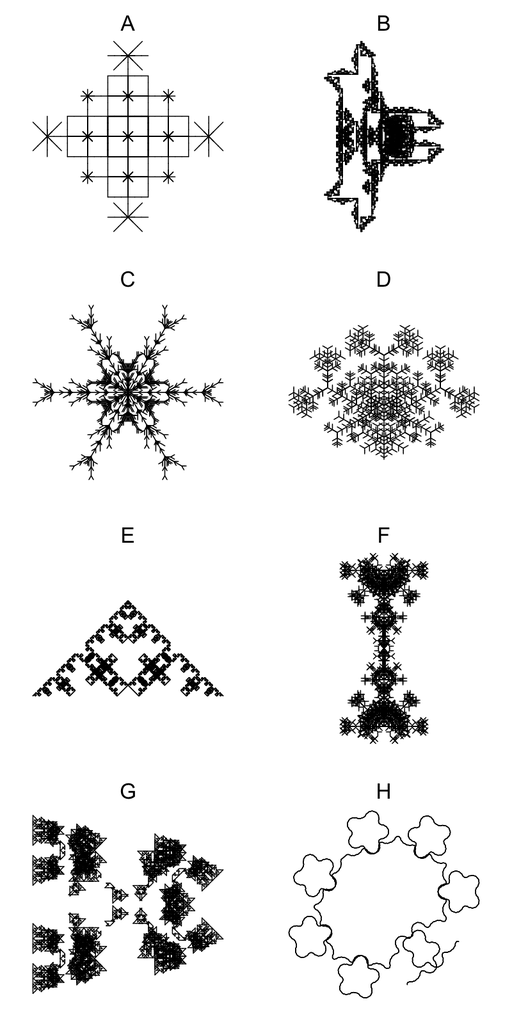

ABCDEFGH

The correct pattern is pattern B.

1. Use the first link: https://artockthedino.github.io/lsys.html
2. Copy/paste the `Axiom`, `Rules`, `Iterations`, and `Turn angle`.
3. Click `Generate Pattern`
4. Back to the quiz, select the matching pattern.

In case you're interested in the parameters of the other patterns shown:

## Pattern A

- Start: `A`
- Rules:  
  `A > [----AAB][--AAB][++AAB]AAB`  
  `B > [-C][+C][--C][++C][---C][+++C]`  
  `C > CAB`
- Number of recursions (number of iterations):
  - 3
- Angle
  - 45

## Pattern B

- Start: `A`
- Rules:  
  `A > A--CBC--A`  
  `B > B+A+B`  
  `C > -CB+BC-`
- Number of recursions (number of iterations):
  - 7
- Angle
  - 90

## Pattern C

- Start: `A++++A++++A`
- Rules:  
  `A > [+BCC][-BCC]`  
  `B > B[-CA][+CA]`  
  `C > CCA`
- Number of recursions (number of iterations):
  - 5
- Angle
  - 30

## Pattern D

- Start: `A`
- Rules:  
  `A > A[-BC][+BC]BC`  
  `B > BB[-ABC][+ABC]`  
  `C > CCC[-CBA][+CBA]`
- Number of recursions (number of iterations):
  - 4
- Angle
  - 60

## Pattern E

- Start: `AA`
- Rules:  
  `A > A++B-C-B++A`  
  `B > B--A+C+A--B`  
  `C > CC`
- Number of recursions (number of iterations):
  - 6
- Angle
  - 45

## Pattern F

- Start: `A++++XA`
- Rules:  
  `A > AA[-B][+B]B`  
  `B > [---ABC][+++ABC]`  
  `C > A[-CB][+CB]`  
  `X > XX`
- Number of recursions (number of iterations):
  - 5
- Angle
  - 45

## Pattern G

- Start: `B`
- Rules:  
  `A > +B-AXA-B+`  
  `B > -BA+BAB+AB-`  
  `X > XX`
- Number of recursions (number of iterations):
  - 5
- Angle
  - 135

## Pattern H

- Start: `A`
- Rules:  
  `A > +BAA-A-CC-A-AAB+`  
  `B > -C+++BAACAAB+++C-`  
  `C > CC`
- Number of recursions (number of iterations):
  - 4
- Angle
  - 10

Consider the $L$-system (and turn angle) defined below:

- Start: `A++A++A++A`
- Rules:  
  `A > B-CAC-B`  
  `B > AB-BA`  
  `C > CC`
- Number of recursions (number of iterations):
  - 5
- Turn angle
  - 135°

Please use [this online tool](https://artockthedino.github.io/lsys.html) to generate the pattern using turtle graphics. Choose the matching pattern. (The initial angle should be $270$ degrees to match the orientation.)

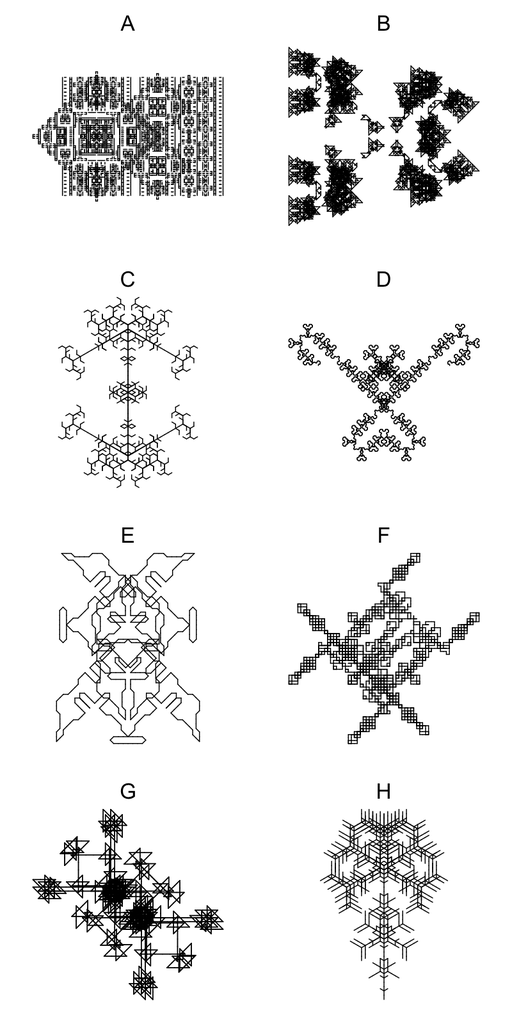

ABCDEFGH

The correct pattern is pattern G.

1. Use the first link: https://artockthedino.github.io/lsys.html
2. Copy/paste the `Axiom`, `Rules`, `Iterations`, and `Turn angle`.
3. Click `Generate Pattern`
4. Back to the quiz, select the matching pattern.

In case you're interested in the parameters of the other patterns shown:

## Pattern A

- Start: `A`
- Rules:  
  `A > +BX-AA-XB+`  
  `B > -AXB+B+BXA-`  
  `X > XX`
- Number of recursions (number of iterations):
  - 6
- Angle
  - 90

## Pattern B

- Start: `B`
- Rules:  
  `A > +B-AXA-B+`  
  `B > -BA+BAB+AB-`  
  `X > XX`
- Number of recursions (number of iterations):
  - 5
- Angle
  - 135

## Pattern C

- Start: `A+++A`
- Rules:  
  `A > BC`  
  `B > B[+C][-C]`  
  `C > CAD`  
  `D > DD[+D+D][-D-D]`
- Number of recursions (number of iterations):
  - 5
- Angle
  - 60

## Pattern D

- Start: `AA`
- Rules:  
  `A > B-AA-B`  
  `B > A+B+A`
- Number of recursions (number of iterations):
  - 6
- Angle
  - 45

## Pattern E

- Start: `A`
- Rules:  
  `A > +BA+A-ABA-A+AB+`  
  `B > +BBA-B--B-ABB+`
- Number of recursions (number of iterations):
  - 3
- Angle
  - 45

## Pattern F

- Start: `A`
- Rules:  
  `A > A--CBC--A`  
  `B > B+C+B`  
  `C > -CB+BC-`
- Number of recursions (number of iterations):
  - 6
- Angle
  - 90

## Pattern G

- Start: `A++A++A++A`
- Rules:  
  `A > B-CAC-B`  
  `B > AB-BA`  
  `C > CC`
- Number of recursions (number of iterations):
  - 5
- Angle
  - 135

## Pattern H

- Start: `A`
- Rules:  
  `A > AA[-B][+B]B`  
  `B > B[-ABC][+ABC]`  
  `C > C[-CBA][+CBA]`
- Number of recursions (number of iterations):
  - 4
- Angle
  - 60